| Bedford Lake | Bedford Lake Club | Town(s) of Bedford | Westchester County |
| --- | --- | --- | --- |

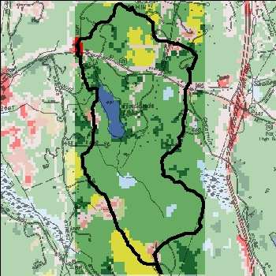

## Bedford Lake – 2018 Sampling Season Results

Open Water Indicators

2018 Sampling Results

Seasonal Change

Season Avg

Decadal Average

Decadal Trend?

Longterm Avg

Longterm Trend?

06-07

06-24

07-08

07-22

08-05

08-19

09-02

09-16

Clarity (m)

1

1.6

1.1

0.9

1

1.6

0.8

0.8

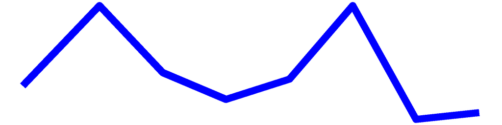

1.1

1.2

1.2

Surface TP (mg/L)

0.047

0.041

0.088

0.114

0.124

0.082

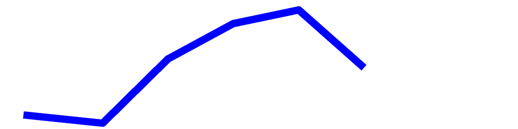

0.082

0.082

Surface TDP (mg/L)

0.012

0.038

0.022

0.032

0.004

0.035

0.017

0.027

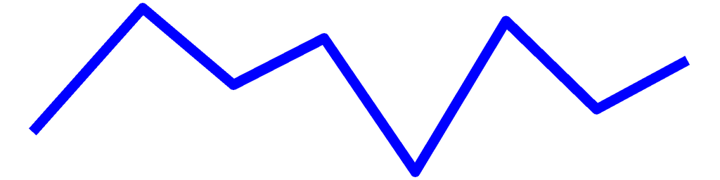

0.023

TN (mg/L)

0.364

0.612

0.997

0.893

0.956

0.751

1.011

1.56

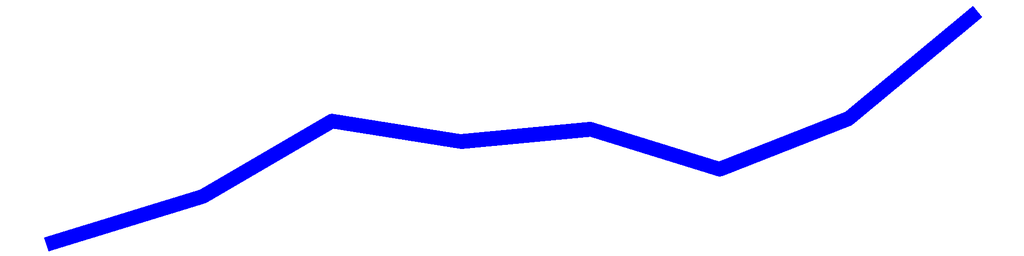

1.008

1.008

TDN (mg/L)

0.35

0.473

0.933

0.88

0.861

0.736

0.812

1.19

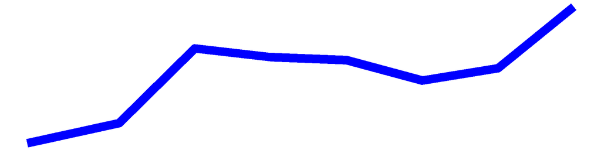

0.779

0.516

0.516

TN:TP

8

15

11

8

8

9

12

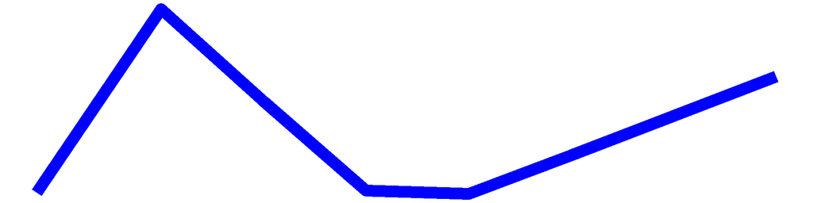

11

15

15

Surface NH3 (mg/L)

0.062

0.126

0.271

0.347

0.15

0.223

0.228

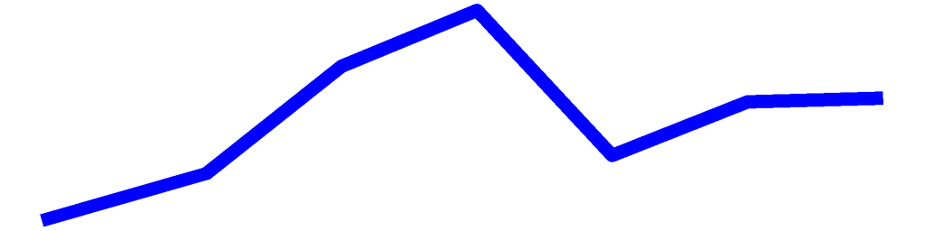

0.201

0.091

0.091

Chl.a (ug/L)

16.9

1.7

26.9

40.4

34.1

14.7

61.6

115.2

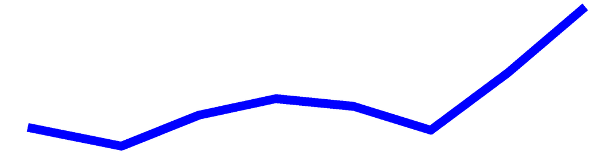

38.9

44.9

44.9

pH

7.9

7.6

7.7

7.6

6.8

7.3

7.5

7.1

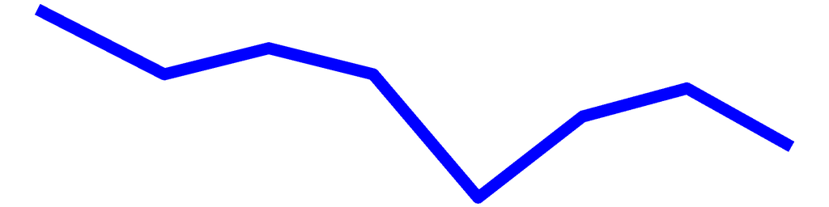

7.4

7.7

7.7

Cond (umho/cm)

296

305

340

316

314

348

324

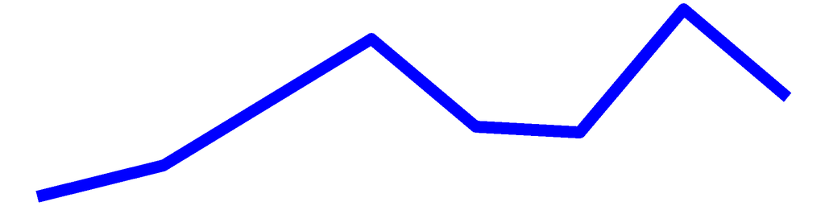

320

262

262

Surface Chloride (mg/L)

58

52

55

52

52

Upper Temp (degC)

16

24

25

27

26

26

26

22

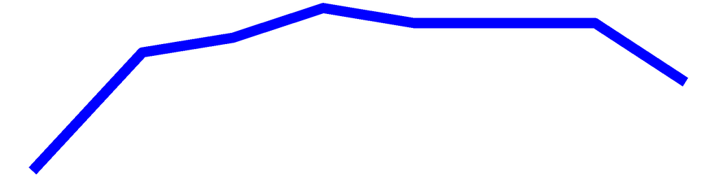

24

24

24

FP BG Chl.a (ug/L)

2.2

11.3

29.4

34.8

3.6

6.6

64.6

23.5

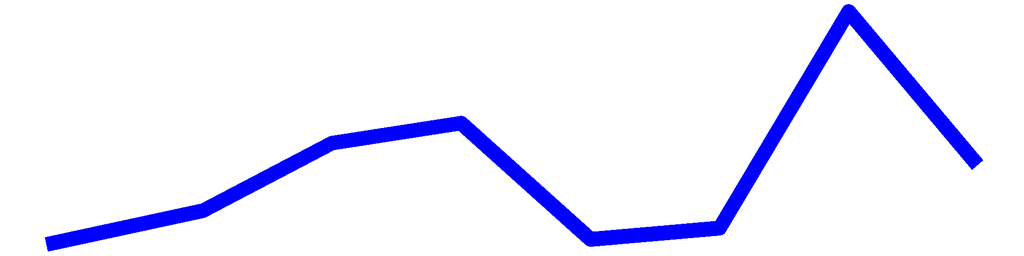

22

18.1

18.1

### NYHABs notifications

#### Were there any reported HABs this season? **Yes.**

| Date of First Listing | Date of Last Listing | Number of Reports |
| --- | --- | --- |
| 07/08/2018 | 09/16/2018 | 202 |

### Shoreline HAB Sample Dates 2018

| HAB Indicators | Criteria | 09-02 | 09-16 |
| --- | --- | --- | --- |
| FP BGA Chl. a | 25 ug/L | 94.76 | 86.38 |
| Microcystin | 20 ug/L | 2.3 | ND |
| Microscopy | Dominant | Anabaena, Woronchinia, Microcystis, Dolichospermum | Woronchinia, Anabaena |

### HABs Status

#### Open Water Algae

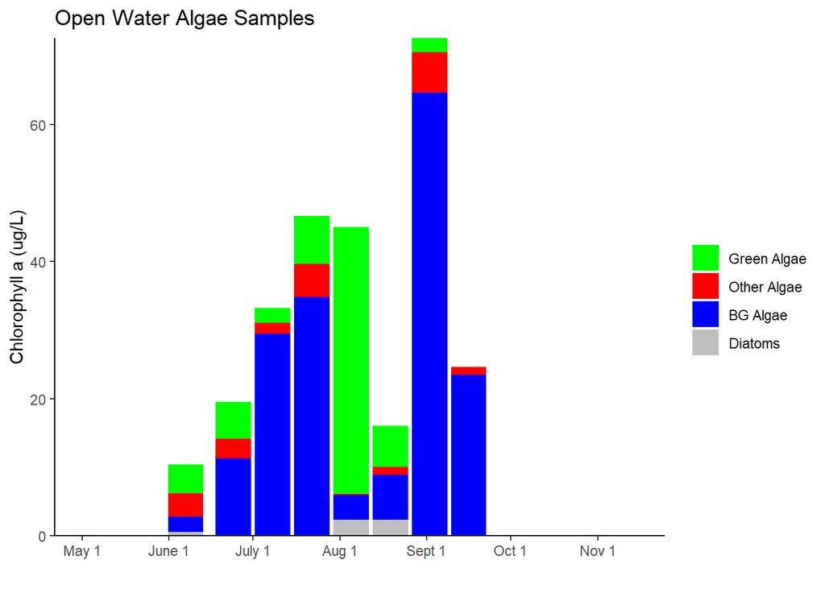

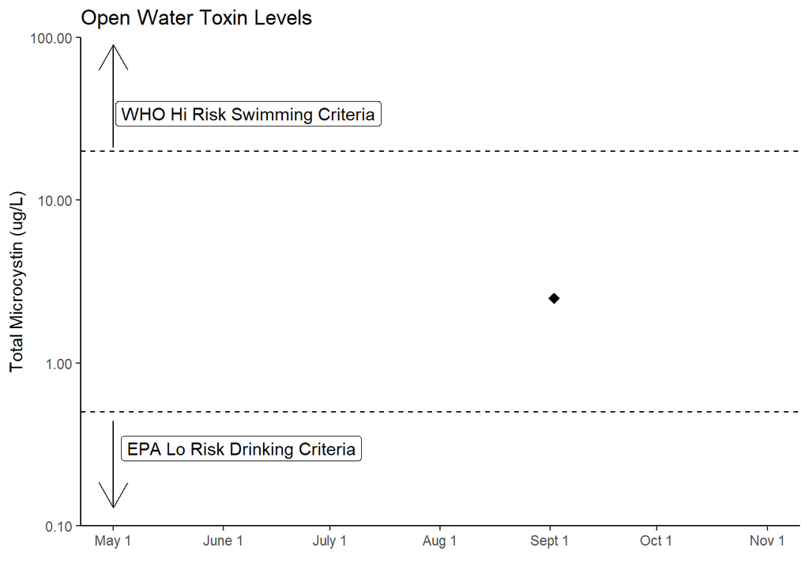

#### Shoreline Algae

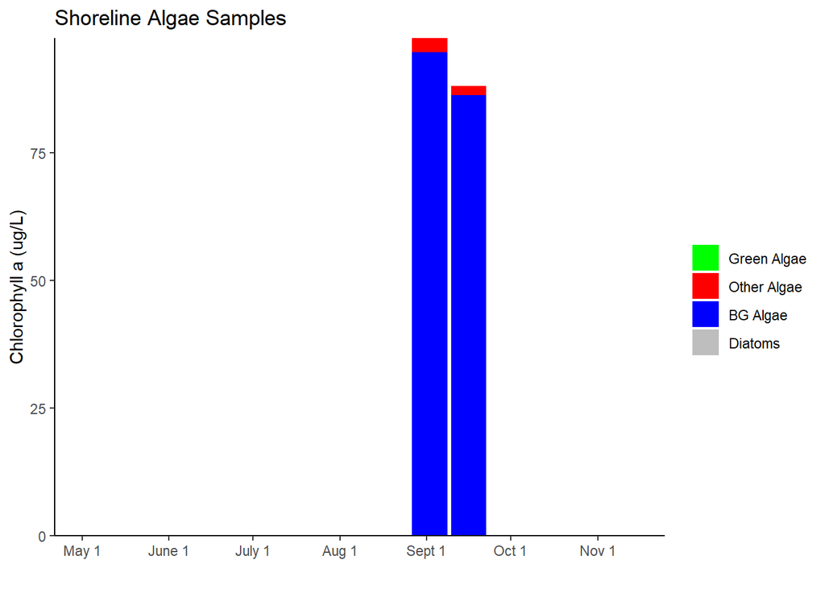

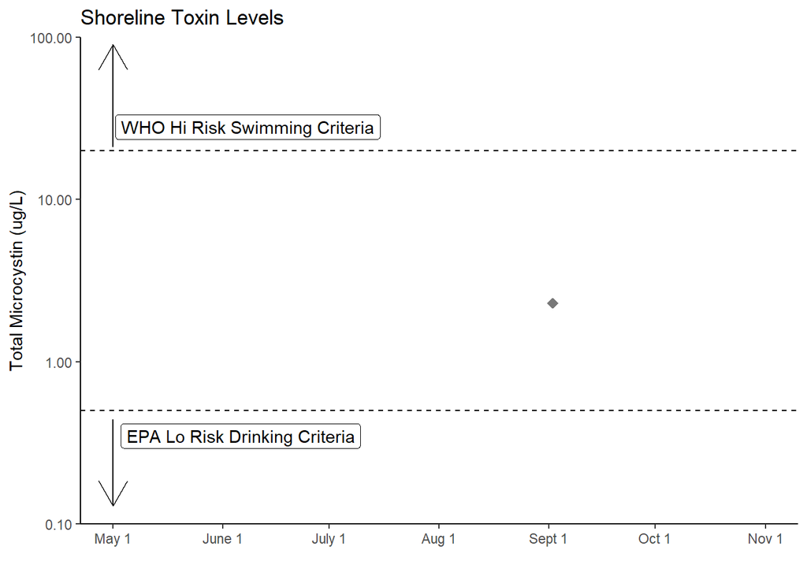

## Bedford Lake Long-Term Trend Analysis

#### Clarity

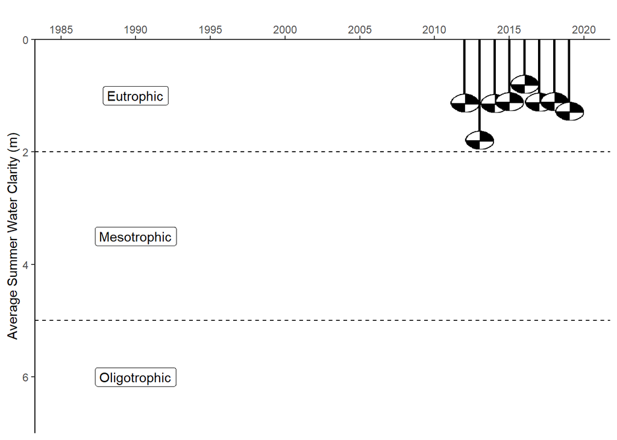

#### Chlorophyll *a*

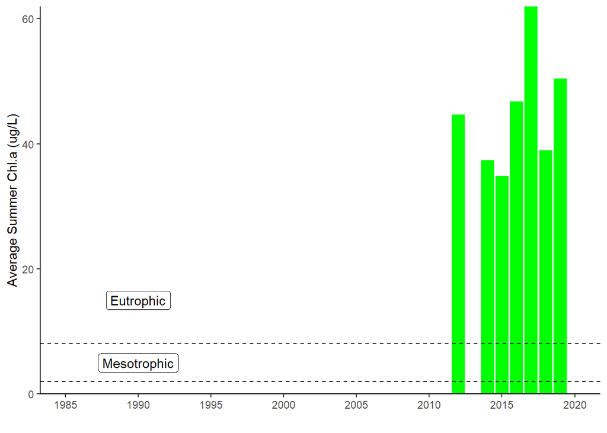

#### Surface and Deep Phosphorus

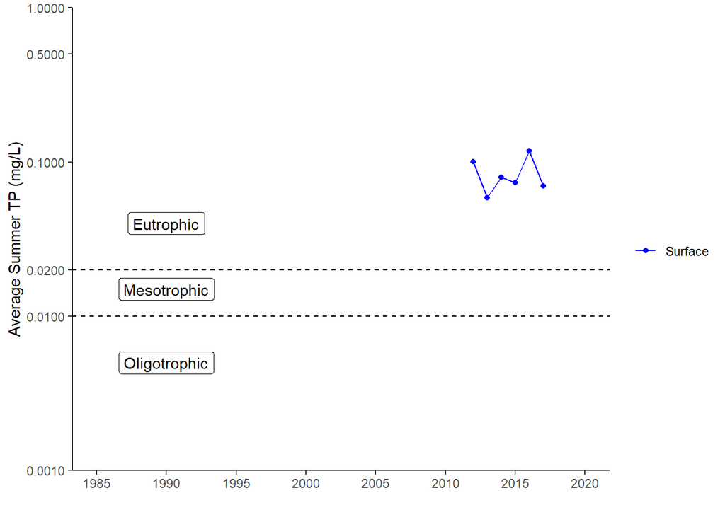

#### Nitrogen

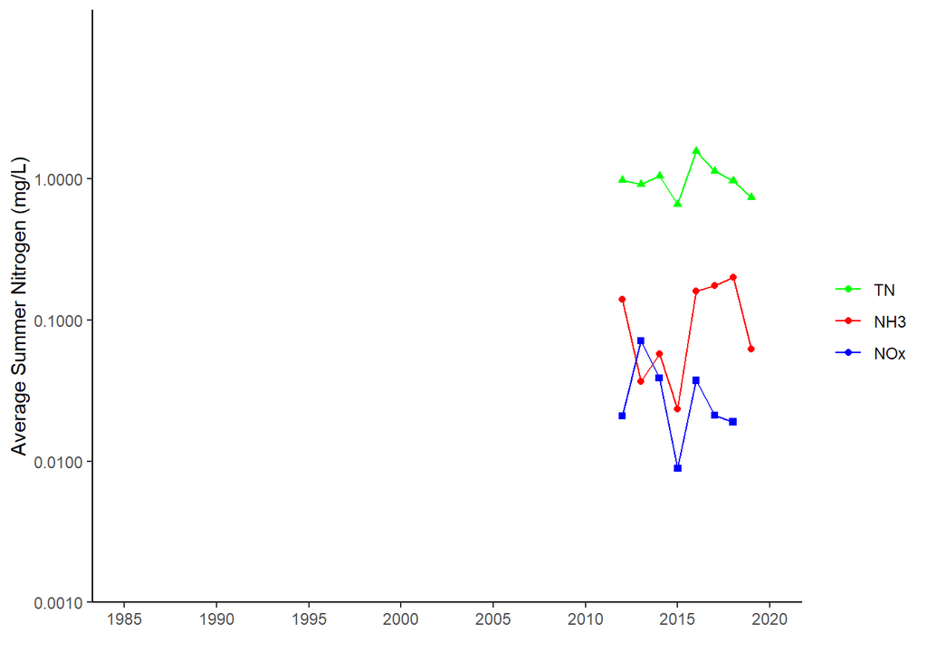

#### TN : TP

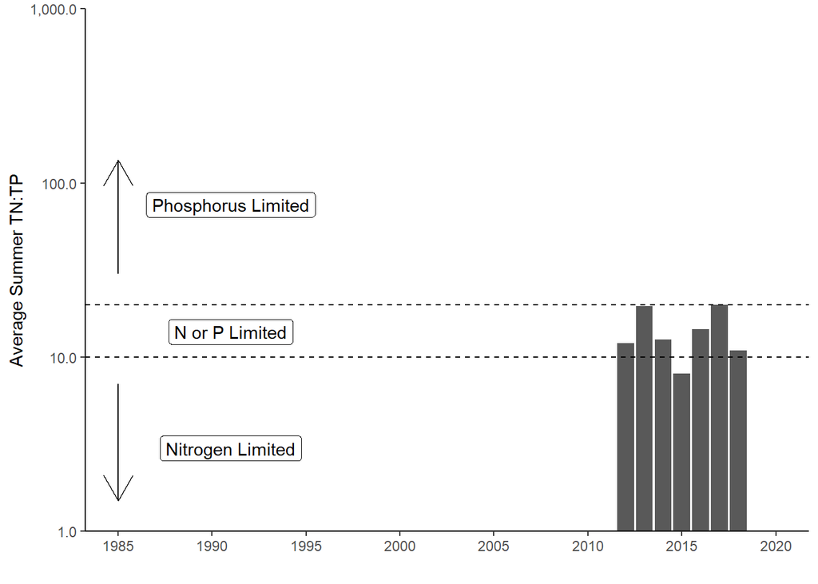

#### pH

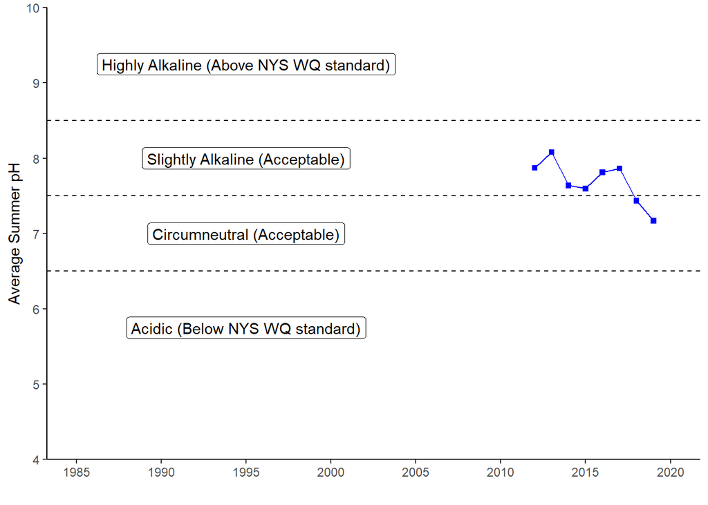

#### Specific Conductance

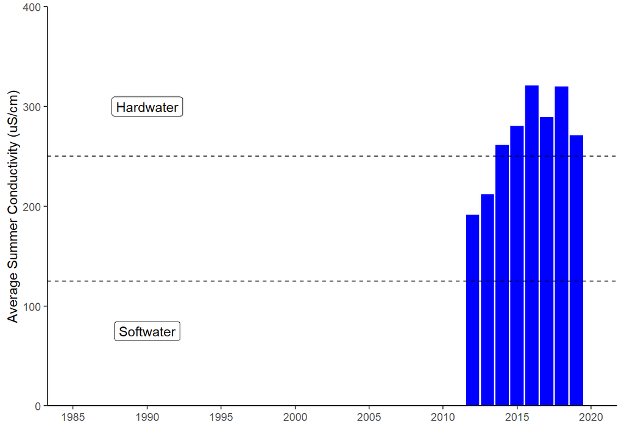

#### Calcium

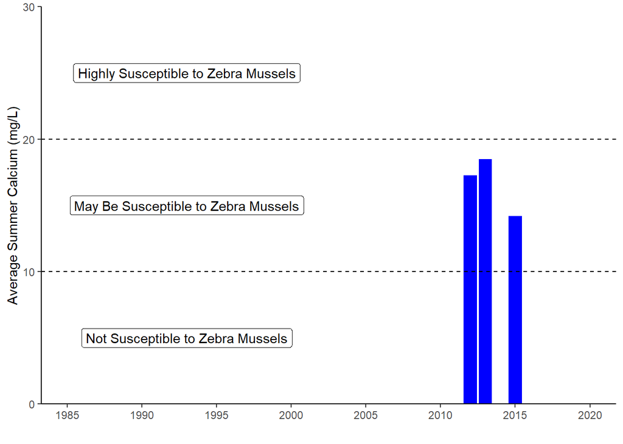

#### Chloride

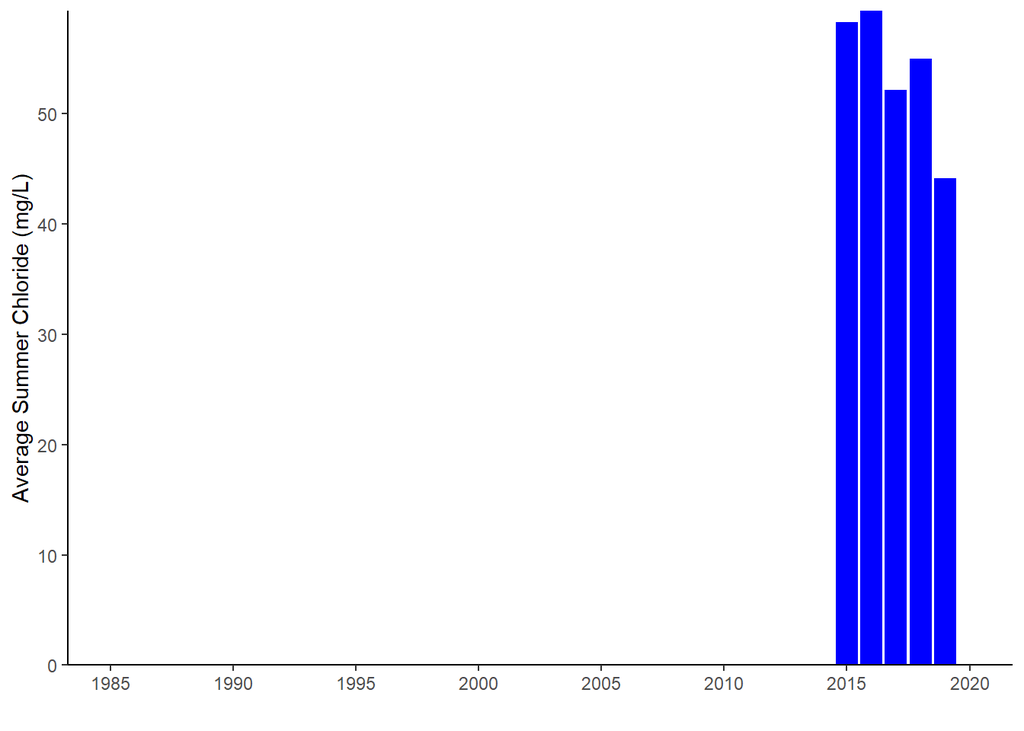

#### Color

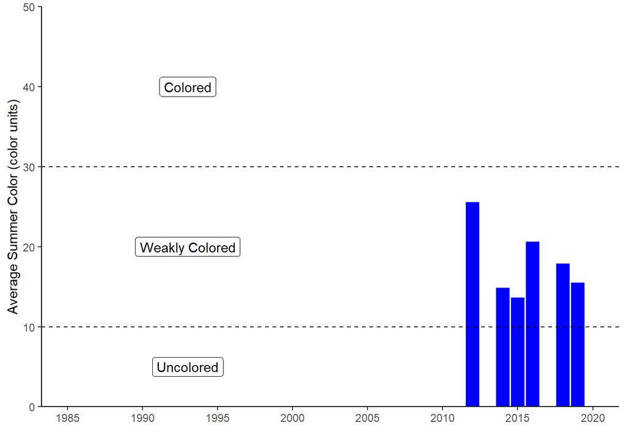

#### Surface and Deep Temperature

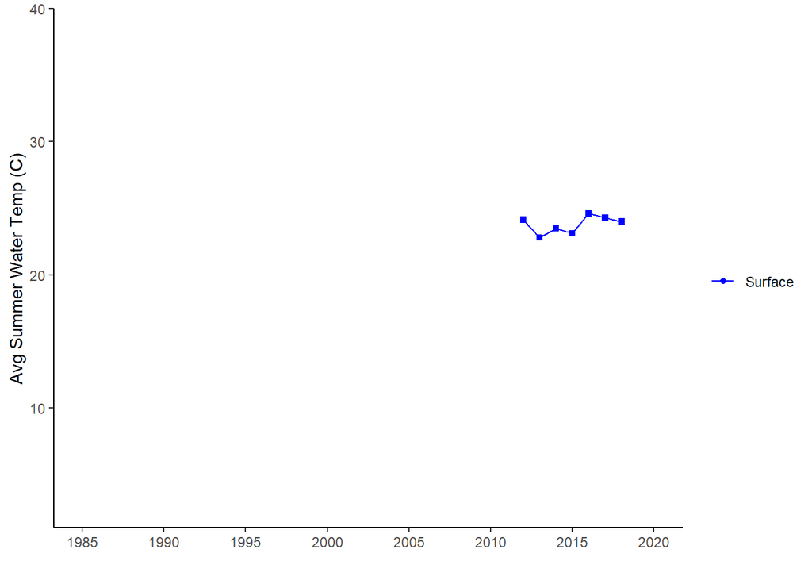

#### Lake Perception

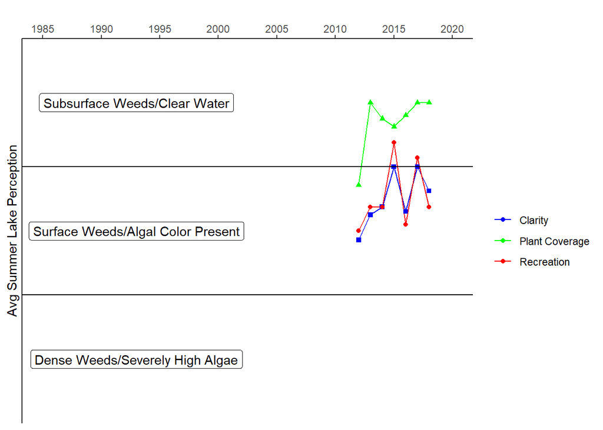

## Bedford Lake - In-Season Analysis

#### In Season Water Clarity

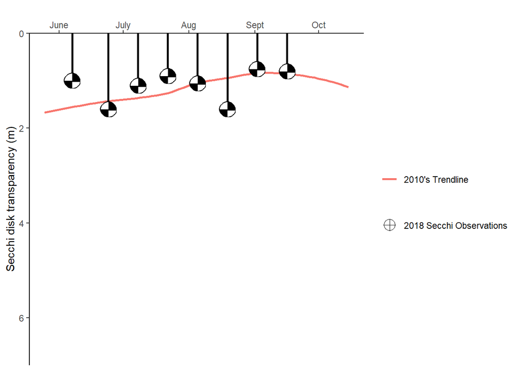

#### In Season Water Temperature

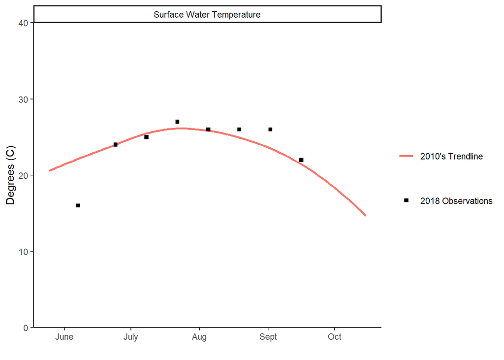

### Bedford Lake – Lake Scorecard

```
## [1] 1
```

[output not shown]

| Aquatic Invasive Species | Present |
| --- | --- |